# Conclusions

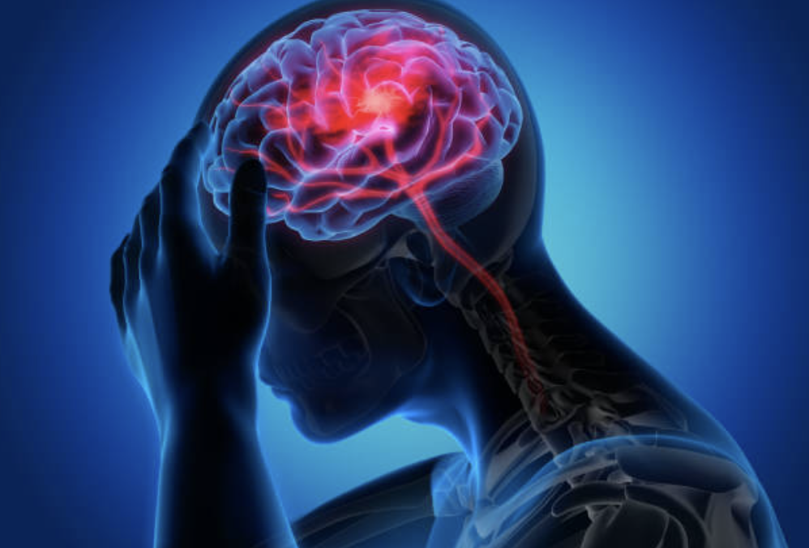

In our comprehensive analysis of stroke risk based on a meticulously curated dataset comprising various personal and medical attributes of patients, we successfully developed a series of visualizations that provide significant insights into key health indicators and their interactions. These insights are instrumental in understanding the complex dynamics of stroke risk factors and offer a robust foundation for targeted intervention strategies and healthcare planning.

Through our exploratory data analysis, we were able to highlight significant patterns and disparities in stroke incidence across different demographic groups. This analysis not only underscored the importance of individual risk factors, such as age, gender, BMI, and glucose levels, but also revealed how these factors interplay with social determinants like marital status, work type, and residence. For instance, we identified certain professions and lifestyles associated with higher stroke risks, which could be due to varying stress levels, physical demands, or differential access to healthcare resources.

Our project employed advanced statistical tools to delve into the relationships between medical indicators such as hypertension, heart disease, and body mass index, and their collective impact on stroke occurrence. This rigorous analytical approach allowed us to pinpoint which factors are most strongly correlated with stroke, providing a data-driven basis for preventive measures. Furthermore, the use of machine learning techniques enabled us to predict stroke risk with significant accuracy, thus opening the door to personalized medical recommendations and proactive health management.

One of the pivotal achievements of this project was the development of interactive and engaging visual narratives that effectively communicate complex data insights to a general audience. These narratives not only foster a deeper understanding of stroke risk factors but also enhance the audience’s ability to make informed health decisions. By integrating interactivity into our visualizations, we facilitated a more personalized exploration of the data, allowing individuals to see how specific changes in lifestyle or health metrics could alter their personal stroke risk.

Moreover, our visualizations served an educational purpose, incrementally building the viewer’s understanding of stroke risks from fundamental concepts to more detailed and specific information. This educational approach ensures that the information is accessible to individuals with varying levels of health literacy, thereby broadening the impact of our findings.

In conclusion, the visualizations and analyses conducted as part of this project not only provide valuable insights into stroke prevention but also demonstrate the power of data visualization in public health. They highlight the critical role that data-driven strategies can play in enhancing healthcare delivery and disease prevention. Our findings advocate for the integration of personalized health data into preventive health strategies, emphasizing the need for a multifaceted approach to health management and education. The project stands as a testament to how visual data storytelling can bridge the gap between complex data analysis and practical, actionable health insights, ultimately fostering a more informed and health-conscious society.